# Анализ продаж магазина

### Анализ скидок

В офлайн ритейле воронка продаж выглядит как “реклама >> трафик >> выбор >> покупка”. Поэтому точкой входа в воронку является анонс акции, скидок и т.д.

Из графика следут, что скидки имеют определенную сезонность: более высокие скидки наблюдаются в первом и третьем кварталах года, более низкие скидки - во втором и четвертом кварталах года.

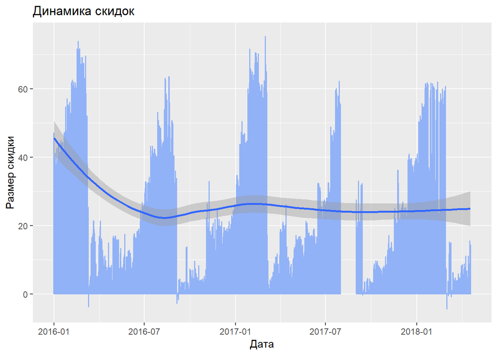

### Анализ трафика

В теории количество трафика в торговой точке обусловлено проводимыми акциями и т.д. Из графика видно, что трафик имел заметный рост с пиком в третьем квартале 2016 г. Вероятно, в этот период проводилась какая-то акция, которая была интересна аудитории магазина.

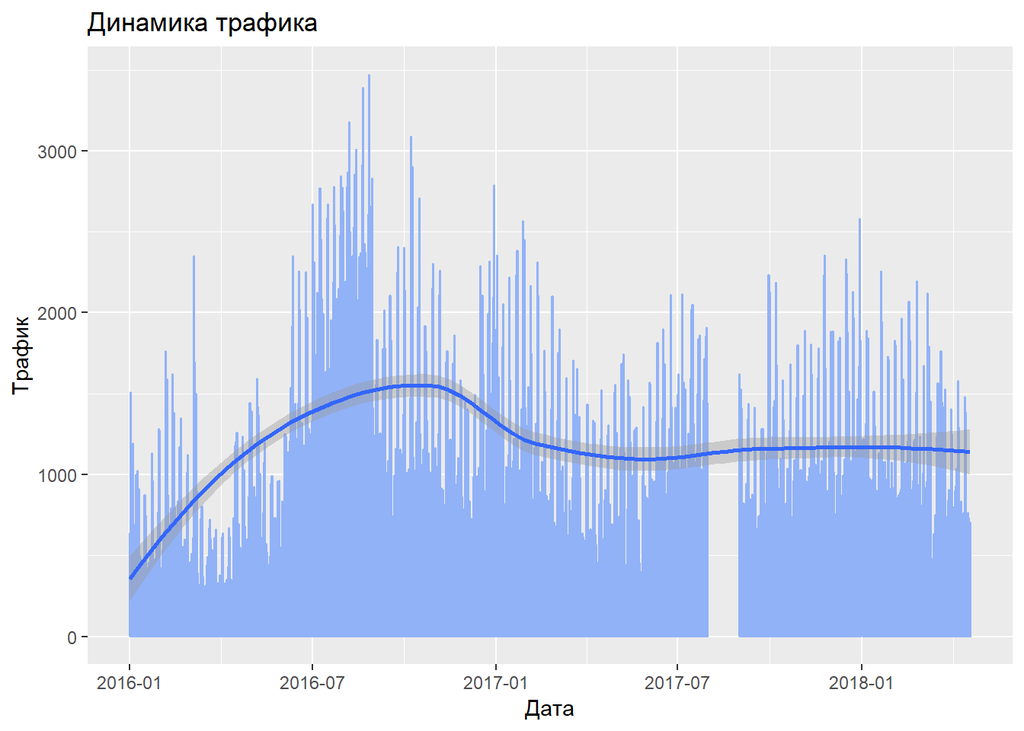

Однако в целом скидки не оказали большого влияния трафика в торговой точке.

Корреляция между размером скидки и трафиком составила 0,22.

```
## [1] 0.220831
```

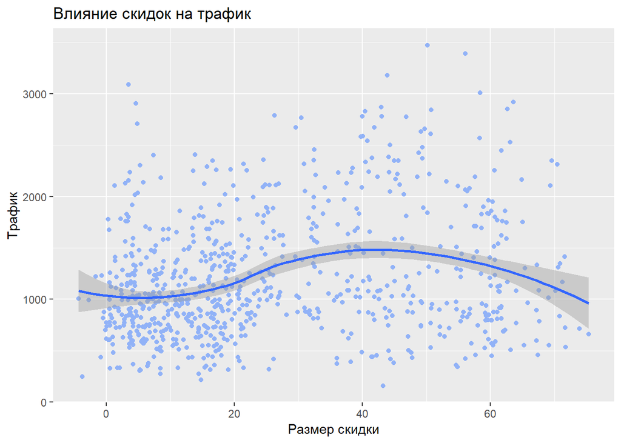

### Анализ персонала

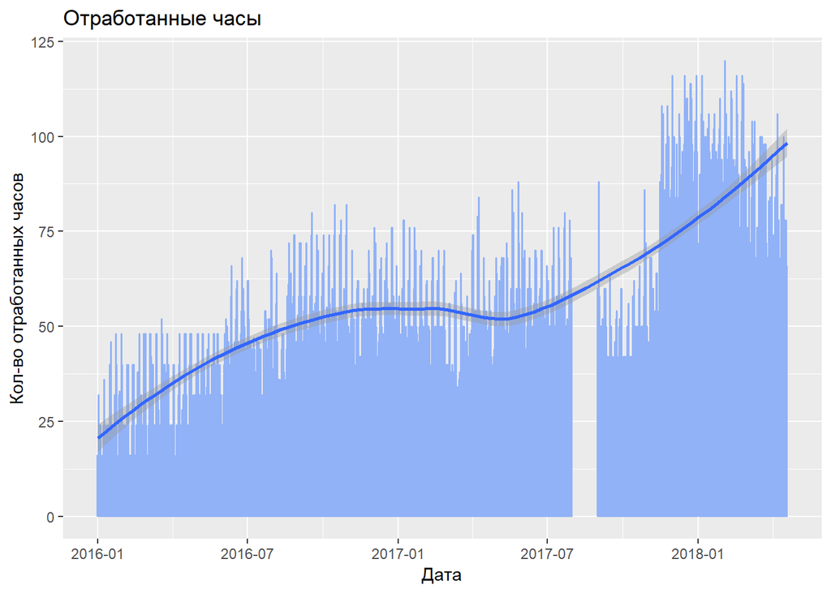

При этом такой рост не существенно влиял на увеличение продаж (корреляция 0,27).

```
## [1] 0.2770169
```

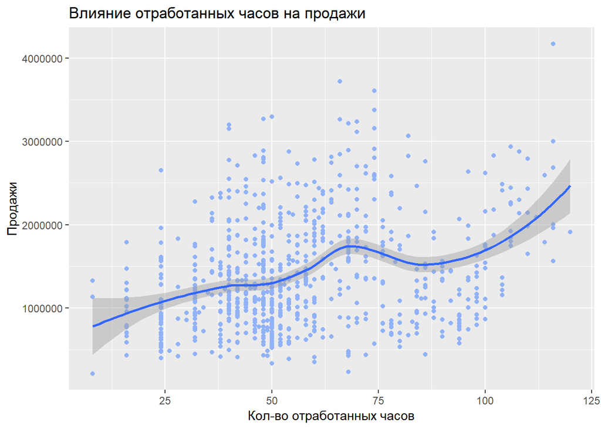

### Анализ количества покупок

Из графика видно, что наблюдается рост количества покупок при увеличении размера скидок.

Корреляция составляет 0,55.

```
## [1] 0.5569932
```

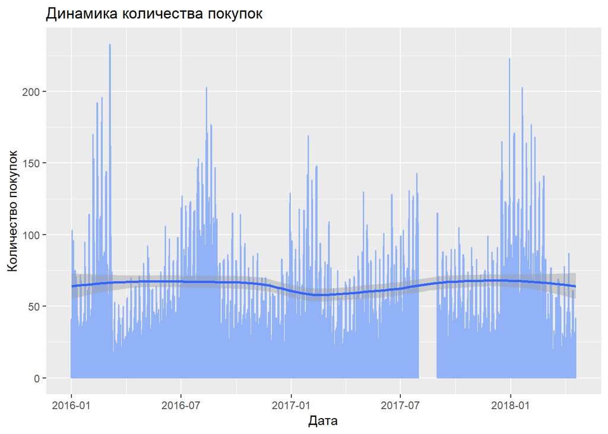

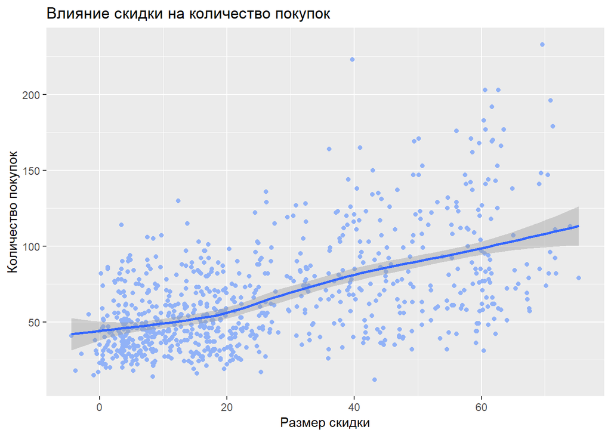

### Анализ среднего чека

Из графика заметно, что в периоды наибольшего размера скидок величина среднего чека снижается.

Корреляция составила -0,68.

```
## [1] -0.681041
```

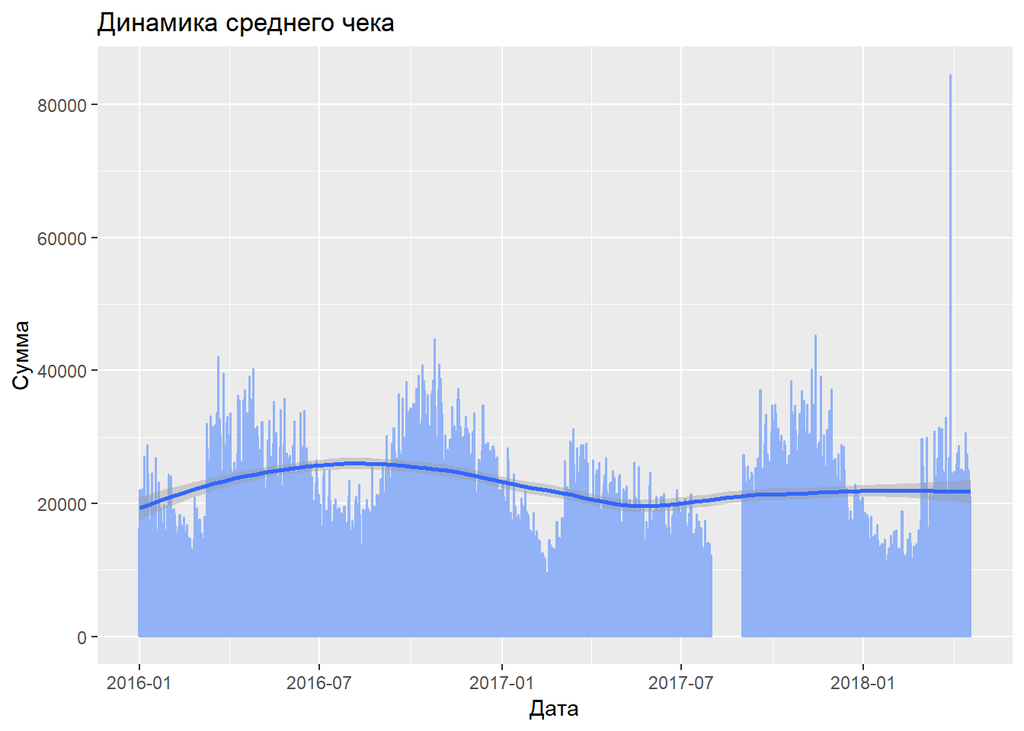

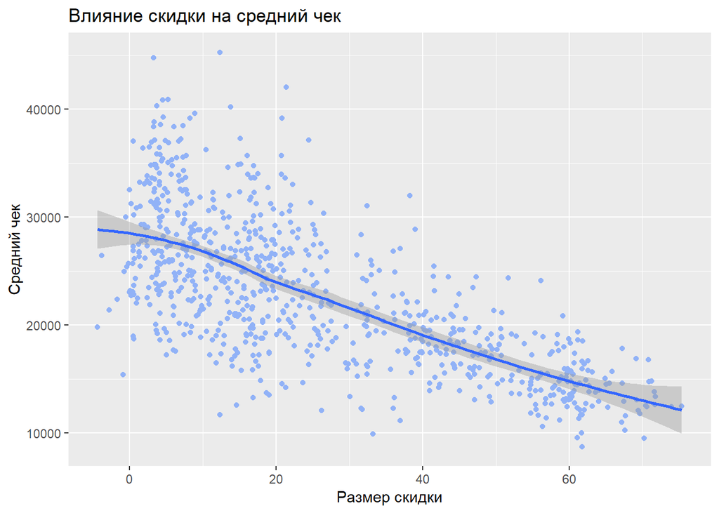

### Анализ количества единиц товара в чеке

Количество товара в чеке на протяжении всего периода остается практически постоянным.

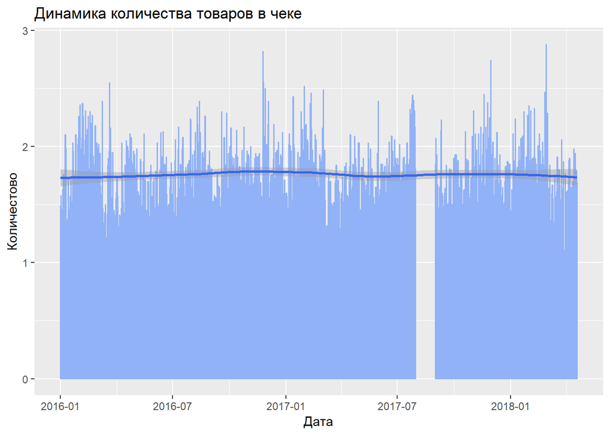

Однако если оценить влияние скидки на этот показатель, то заметно, что размер скидки умеренно влияет на среднее количество товара в чеке. При этом ярко-выраженной позитивной динкамики не наблюдается.

Корреляция составила 0,39.

```
## [1] 0.3946687
```

Это может быть следствием ограниченного ассортимента в магазине, или из-за неготовности посетителей покупать больше товара даже при наличии высокой скидки.

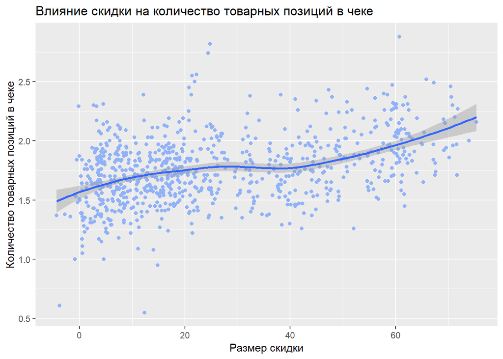

### Анализ продаж

На графике заметно небольшое повышение продаж в третьем квартале 2016 г. Однако существенно объем продаж по времени не меняется.

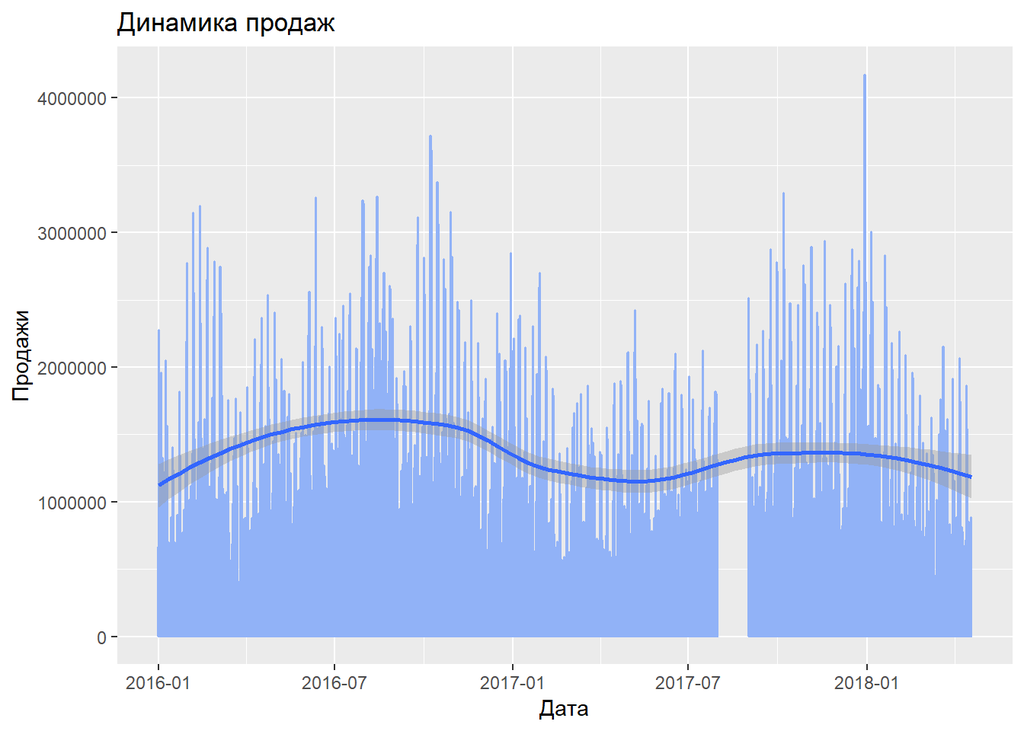

Из графика заметно, что количество трафика влияет на продажи. Корреляция 0,79.

```
## [1] 0.799511
```

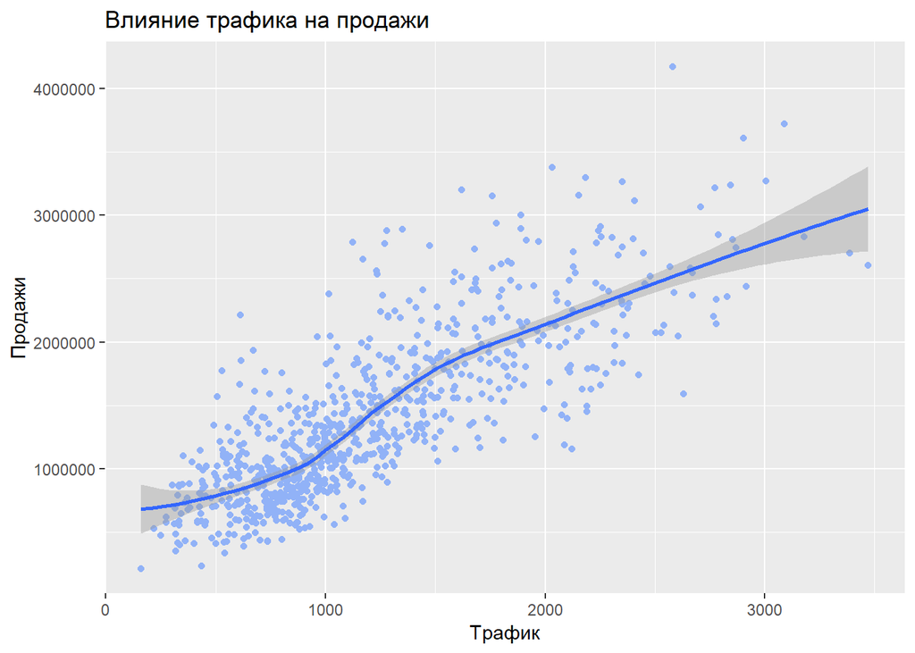

При этом размер скидки не оказывает на продажи существенного влияния. Об этом же свидетельствует и корреляция размера скидки и продаж:

```
## [1] 0.1113434
```

Небольшой рост продаж наблюдается лишь при размере скидки в районе 40%. Однако, при бОльшем размере скидки роста продаж не происходит.

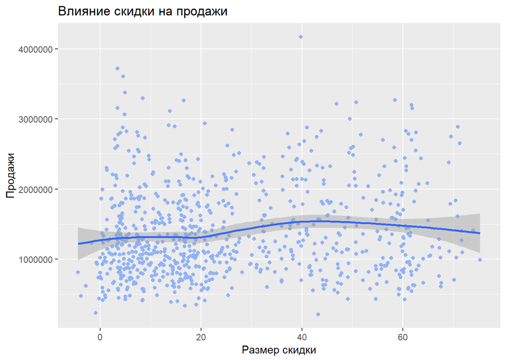

Величина среднего чека так же существенно не влияет на продажи.

Корреляция 0,16.

```
## [1] 0.1690716
```

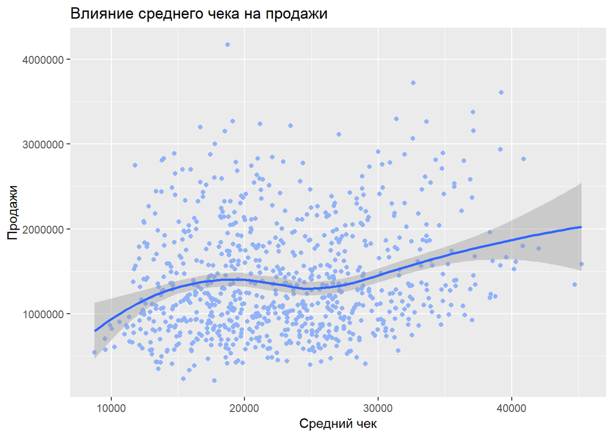

Количество единиц товара в чеке умеренно влияет на продажи (корреляция 0,33).

```
## [1] 0.335213
```

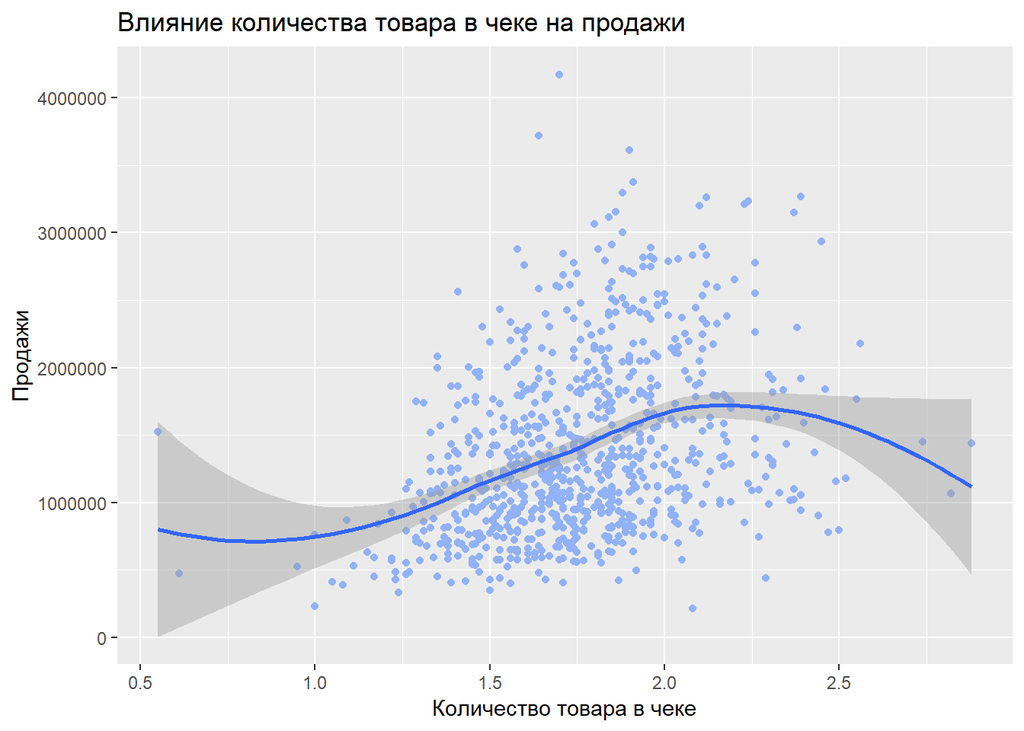

Количество покупок также влияет на продажи (корреляция 0,77).

```
## [1] 0.7725901
```

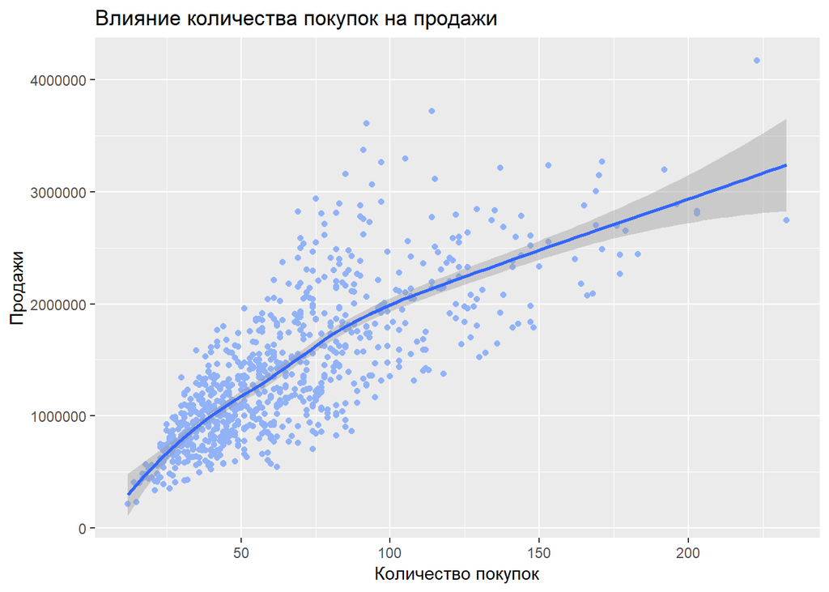

### Выводы

Скидки влияют на количество покупок, но размер скидки снижает стоимость среднего чека. Таким образом, в денежном выражении роста продаж не происходит.

Это говорит о том, что высокие скидки по факту не являются дастаточным мотиватором для посещения магазина (за исключением третьего квартала 2016 г.) и увеличения количества товарных позиций в чеке, что в свою очередь не оказывают большого влияения на продажи в денежном выражении.

### Рекомендации:

На основе выявленных инсайтов руководству торговой точки рекомендуется:

- поресмотреть политику скидок и акций, сделав их более привлекательными для аудитории, что повысит трафик;
- пересмотреть размер скидок, который при увеличении числа покупок будет давать рост продаж в денежном выражении.
- пересмотреть ассортиментную политику, что позволит продавать больше товарных позиций (количество товара в чеке).